# Project: Investigate a Dataset - [ For TMDb Movie Dataset]

- Introduction
- Data Wrangling
- Exploratory Data Analysis
- Conclusions

## Introduction

### Dataset Description

In order to do my data analysis project_one (Investigate_Dataset) I will be using **TMDb movie dataset**. This data set contains information about 10,000 movies collected from The Movie Database (TMDb), and 21 columns such as id,imdb_id,revenue,budget,popularity,cast etc.I would like to explore other important patterns in the datasets.

### Question(s) for Analysis

> - Q1: Which movie has the highst and lowest budget ?
> - Q2: movies having the longest and shortest runtime ?
> - Q3: Top 5 Movies with the highest budget ?
> - Q4: Average runtime of the movies ?
> - Q5:Most movies from which geners?

```python
# Use this cell to set up import statements for all of the packages that you
#   plan to use.

# Remember to include a 'magic word' so that your visualizations are plotted
#   inline with the notebook. See this page for more:
#   http://ipython.readthedocs.io/en/stable/interactive/magics.html
import pandas as pd
import numpy as np
import seaborn as sns
import matplotlib.pyplot as plt
%matplotlib inline
%config InlineBackend.figure_format="retina"
```

```python
# Upgrade pandas to use dataframe.explode() function.
#!pip install --upgrade pandas==0.25.
```

## Data Wrangling

The steps to be followed in data wrangling are:

I) Data gathering

II) Data Assessing

III) Data Cleaning

### I) Data Gathering (Loading The Dataset)

```python
# Load the data and print out a few lines. Perform operations to inspect data
#   types and look for instances of missing or possibly errant data.
df_movie=pd.read_csv("tmdb-movies.csv")
df_movie.head()
```

|  | id | imdb_id | popularity | budget | revenue | original_title | cast | homepage | director | tagline | ... | overview | runtime | genres | production_companies | release_date | vote_count | vote_average | release_year | budget_adj | revenue_adj |
| --- | --- | --- | --- | --- | --- | --- | --- | --- | --- | --- | --- | --- | --- | --- | --- | --- | --- | --- | --- | --- | --- |
| 0 | 135397 | tt0369610 | 32.985763 | 150000000 | 1513528810 | Jurassic World | Chris Pratt\|Bryce Dallas Howard\|Irrfan Khan\|Vi... | http://www.jurassicworld.com/ | Colin Trevorrow | The park is open. | ... | Twenty-two years after the events of Jurassic ... | 124 | Action\|Adventure\|Science Fiction\|Thriller | Universal Studios\|Amblin Entertainment\|Legenda... | 6/9/15 | 5562 | 6.5 | 2015 | 1.379999e+08 | 1.392446e+09 |
| 1 | 76341 | tt1392190 | 28.419936 | 150000000 | 378436354 | Mad Max: Fury Road | Tom Hardy\|Charlize Theron\|Hugh Keays-Byrne\|Nic... | http://www.madmaxmovie.com/ | George Miller | What a Lovely Day. | ... | An apocalyptic story set in the furthest reach... | 120 | Action\|Adventure\|Science Fiction\|Thriller | Village Roadshow Pictures\|Kennedy Miller Produ... | 5/13/15 | 6185 | 7.1 | 2015 | 1.379999e+08 | 3.481613e+08 |
| 2 | 262500 | tt2908446 | 13.112507 | 110000000 | 295238201 | Insurgent | Shailene Woodley\|Theo James\|Kate Winslet\|Ansel... | http://www.thedivergentseries.movie/#insurgent | Robert Schwentke | One Choice Can Destroy You | ... | Beatrice Prior must confront her inner demons ... | 119 | Adventure\|Science Fiction\|Thriller | Summit Entertainment\|Mandeville Films\|Red Wago... | 3/18/15 | 2480 | 6.3 | 2015 | 1.012000e+08 | 2.716190e+08 |
| 3 | 140607 | tt2488496 | 11.173104 | 200000000 | 2068178225 | Star Wars: The Force Awakens | Harrison Ford\|Mark Hamill\|Carrie Fisher\|Adam D... | http://www.starwars.com/films/star-wars-episod... | J.J. Abrams | Every generation has a story. | ... | Thirty years after defeating the Galactic Empi... | 136 | Action\|Adventure\|Science Fiction\|Fantasy | Lucasfilm\|Truenorth Productions\|Bad Robot | 12/15/15 | 5292 | 7.5 | 2015 | 1.839999e+08 | 1.902723e+09 |
| 4 | 168259 | tt2820852 | 9.335014 | 190000000 | 1506249360 | Furious 7 | Vin Diesel\|Paul Walker\|Jason Statham\|Michelle ... | http://www.furious7.com/ | James Wan | Vengeance Hits Home | ... | Deckard Shaw seeks revenge against Dominic Tor... | 137 | Action\|Crime\|Thriller | Universal Pictures\|Original Film\|Media Rights ... | 4/1/15 | 2947 | 7.3 | 2015 | 1.747999e+08 | 1.385749e+09 |

5 rows × 21 columns

```python
# Displayingthe lastThree rows
df_movie.tail(3)
```

|  | id | imdb_id | popularity | budget | revenue | original_title | cast | homepage | director | tagline | ... | overview | runtime | genres | production_companies | release_date | vote_count | vote_average | release_year | budget_adj | revenue_adj |
| --- | --- | --- | --- | --- | --- | --- | --- | --- | --- | --- | --- | --- | --- | --- | --- | --- | --- | --- | --- | --- | --- |
| 10863 | 39768 | tt0060161 | 0.065141 | 0 | 0 | Beregis Avtomobilya | Innokentiy Smoktunovskiy\|Oleg Efremov\|Georgi Z... | NaN | Eldar Ryazanov | NaN | ... | An insurance agent who moonlights as a carthie... | 94 | Mystery\|Comedy | Mosfilm | 1/1/66 | 11 | 6.5 | 1966 | 0.000000 | 0.0 |
| 10864 | 21449 | tt0061177 | 0.064317 | 0 | 0 | What's Up, Tiger Lily? | Tatsuya Mihashi\|Akiko Wakabayashi\|Mie Hama\|Joh... | NaN | Woody Allen | WOODY ALLEN STRIKES BACK! | ... | In comic Woody Allen's film debut, he took the... | 80 | Action\|Comedy | Benedict Pictures Corp. | 11/2/66 | 22 | 5.4 | 1966 | 0.000000 | 0.0 |
| 10865 | 22293 | tt0060666 | 0.035919 | 19000 | 0 | Manos: The Hands of Fate | Harold P. Warren\|Tom Neyman\|John Reynolds\|Dian... | NaN | Harold P. Warren | It's Shocking! It's Beyond Your Imagination! | ... | A family gets lost on the road and stumbles up... | 74 | Horror | Norm-Iris | 11/15/66 | 15 | 1.5 | 1966 | 127642.279154 | 0.0 |

3 rows × 21 columns

```python
df_movie.info()
```

```
<class 'pandas.core.frame.DataFrame'>
RangeIndex: 10866 entries, 0 to 10865
Data columns (total 21 columns):
id                      10866 non-null int64
imdb_id                 10856 non-null object
popularity              10866 non-null float64
budget                  10866 non-null int64
revenue                 10866 non-null int64
original_title          10866 non-null object
cast                    10790 non-null object
homepage                2936 non-null object
director                10822 non-null object
tagline                 8042 non-null object
keywords                9373 non-null object
overview                10862 non-null object
runtime                 10866 non-null int64
genres                  10843 non-null object
production_companies    9836 non-null object
release_date            10866 non-null object
vote_count              10866 non-null int64
vote_average            10866 non-null float64
release_year            10866 non-null int64
budget_adj              10866 non-null float64
revenue_adj             10866 non-null float64
dtypes: float64(4), int64(6), object(11)
memory usage: 1.7+ MB
```

### II) Data Assessing

After loading the data I will use Pandas to find some important methods for assessing and building intuition about the dataset, then I will go next with the cleaning process to include only the relavent data related to the questions I will apply on the dataset for the analysis process and remove the unnecessary data.

```python
#to find dimension of the dataset
df_movie.shape
```

```
(10866, 21)
```

So ,The dataset have 10866 rows and 21 columns

```python
df_movie.dtypes
```

```
id                        int64
imdb_id                  object
popularity              float64
budget                    int64
revenue                   int64
original_title           object
cast                     object
homepage                 object
director                 object
tagline                  object
keywords                 object
overview                 object
runtime                   int64
genres                   object
production_companies     object
release_date             object
vote_count                int64
vote_average            float64
release_year              int64
budget_adj              float64
revenue_adj             float64
dtype: object
```

```python
#Describe the statistical summery of the data
df_movie.describe()
```

|  | id | popularity | budget | revenue | runtime | vote_count | vote_average | release_year | budget_adj | revenue_adj |
| --- | --- | --- | --- | --- | --- | --- | --- | --- | --- | --- |
| count | 10866.000000 | 10866.000000 | 1.086600e+04 | 1.086600e+04 | 10866.000000 | 10866.000000 | 10866.000000 | 10866.000000 | 1.086600e+04 | 1.086600e+04 |
| mean | 66064.177434 | 0.646441 | 1.462570e+07 | 3.982332e+07 | 102.070863 | 217.389748 | 5.974922 | 2001.322658 | 1.755104e+07 | 5.136436e+07 |
| std | 92130.136561 | 1.000185 | 3.091321e+07 | 1.170035e+08 | 31.381405 | 575.619058 | 0.935142 | 12.812941 | 3.430616e+07 | 1.446325e+08 |
| min | 5.000000 | 0.000065 | 0.000000e+00 | 0.000000e+00 | 0.000000 | 10.000000 | 1.500000 | 1960.000000 | 0.000000e+00 | 0.000000e+00 |
| 25% | 10596.250000 | 0.207583 | 0.000000e+00 | 0.000000e+00 | 90.000000 | 17.000000 | 5.400000 | 1995.000000 | 0.000000e+00 | 0.000000e+00 |
| 50% | 20669.000000 | 0.383856 | 0.000000e+00 | 0.000000e+00 | 99.000000 | 38.000000 | 6.000000 | 2006.000000 | 0.000000e+00 | 0.000000e+00 |
| 75% | 75610.000000 | 0.713817 | 1.500000e+07 | 2.400000e+07 | 111.000000 | 145.750000 | 6.600000 | 2011.000000 | 2.085325e+07 | 3.369710e+07 |
| max | 417859.000000 | 32.985763 | 4.250000e+08 | 2.781506e+09 | 900.000000 | 9767.000000 | 9.200000 | 2015.000000 | 4.250000e+08 | 2.827124e+09 |

```python
#Display Summery of the dataframe
df_movie.info()
```

```
<class 'pandas.core.frame.DataFrame'>
RangeIndex: 10866 entries, 0 to 10865
Data columns (total 21 columns):
id                      10866 non-null int64
imdb_id                 10856 non-null object
popularity              10866 non-null float64
budget                  10866 non-null int64
revenue                 10866 non-null int64
original_title          10866 non-null object
cast                    10790 non-null object
homepage                2936 non-null object
director                10822 non-null object
tagline                 8042 non-null object
keywords                9373 non-null object
overview                10862 non-null object
runtime                 10866 non-null int64
genres                  10843 non-null object
production_companies    9836 non-null object
release_date            10866 non-null object
vote_count              10866 non-null int64
vote_average            10866 non-null float64
release_year            10866 non-null int64
budget_adj              10866 non-null float64
revenue_adj             10866 non-null float64
dtypes: float64(4), int64(6), object(11)
memory usage: 1.7+ MB
```

From the above summery of the datset Some columns are contain the NaN value(missing values) which means these column will be cleaned in the following step.

```python
# Find Missing Values (null_values)
df_movie.isnull().any()
```

```
id                      False
imdb_id                  True
popularity              False
budget                  False
revenue                 False
original_title          False
cast                     True
homepage                 True
director                 True
tagline                  True
keywords                 True
overview                 True
runtime                 False
genres                   True
production_companies     True
release_date            False
vote_count              False
vote_average            False
release_year            False
budget_adj              False
revenue_adj             False
dtype: bool
```

```python
# Find Total number of null values
df_movie.isnull().any().sum()
```

```
9
```

So there are **9** columns with null values ,i will replace Those null values into zero.

### III) Data Cleaning

#### i) Checking and removing Duplicated Rows in the Dataset

```python
# To find the number of duplicated Data
df_movie.duplicated().any().sum()
```

```
1
```

**Notice:** There is one duplicated data in the dataset,so i have to drope/remove the duplicated row.

#### **Remove Duplicate Rows**

```python
#Drop/remove duplicated Data
df_movie.drop_duplicates(inplace=True)
```

```python
df_movie.shape
```

```
(10865, 21)
```

One duplicated row is removed

#### ii) Removing unused columns which are not used in the analysis process

> According to the research question above, it is clear that not all columns are needed for analysis. Thus, the unused columns wil be removed and only relevant columns for the analysis questions are kept for the further analysis. So The columns I'm going to delete will be: id, imdb_id,revenue, revenue_adj,tagline,cast,release_date,homepage, keywords, overview, vote_count, vote_average and budget_adj:

```python
# Drop The unused Columns
columns_to_Drop= ['id', 'imdb_id','revenue','revenue_adj', 'cast', 'homepage','release_date',
                  'tagline', 'keywords', 'overview', 'vote_count','vote_average',"budget_adj"]
df_movie.drop(columns_to_Drop,axis=1,inplace=True)
df_movie.head()
```

|  | popularity | budget | original_title | director | runtime | genres | production_companies | release_year |
| --- | --- | --- | --- | --- | --- | --- | --- | --- |
| 0 | 32.985763 | 150000000 | Jurassic World | Colin Trevorrow | 124 | Action\|Adventure\|Science Fiction\|Thriller | Universal Studios\|Amblin Entertainment\|Legenda... | 2015 |
| 1 | 28.419936 | 150000000 | Mad Max: Fury Road | George Miller | 120 | Action\|Adventure\|Science Fiction\|Thriller | Village Roadshow Pictures\|Kennedy Miller Produ... | 2015 |
| 2 | 13.112507 | 110000000 | Insurgent | Robert Schwentke | 119 | Adventure\|Science Fiction\|Thriller | Summit Entertainment\|Mandeville Films\|Red Wago... | 2015 |
| 3 | 11.173104 | 200000000 | Star Wars: The Force Awakens | J.J. Abrams | 136 | Action\|Adventure\|Science Fiction\|Fantasy | Lucasfilm\|Truenorth Productions\|Bad Robot | 2015 |
| 4 | 9.335014 | 190000000 | Furious 7 | James Wan | 137 | Action\|Crime\|Thriller | Universal Pictures\|Original Film\|Media Rights ... | 2015 |

#### iii) Changing by Zero with NAN in runtime column

```python
#Change NAN with 0 of runtime column
df_movie['runetime']=df_movie.runtime.replace(0,np.NAN)
```

#### iv) Change and remove NAN with 0 in Budget column

```python
#Change and remove NAN with 0 in Budget column
df_movie['budget']=df_movie.budget.replace(np.NAN,0)
```

```python
# check the removed NAN values in Budget
df_movie.budget.isnull().sum()
```

```
0
```

**Notice:** The NAN values in budget is successfully replaced by zero

#### v) Checking Data type

```python
# Check data type for budget
df_movie.dtypes
```

```
popularity              float64
budget                    int64
original_title           object
director                 object
runtime                   int64
genres                   object
production_companies     object
release_year              int64
runetime                float64
dtype: object
```

```python
df_movie.describe()
```

|  | popularity | budget | runtime | release_year | runetime |
| --- | --- | --- | --- | --- | --- |
| count | 10865.000000 | 1.086500e+04 | 10865.000000 | 10865.000000 | 10834.000000 |
| mean | 0.646446 | 1.462429e+07 | 102.071790 | 2001.321859 | 102.363855 |
| std | 1.000231 | 3.091428e+07 | 31.382701 | 12.813260 | 30.948225 |
| min | 0.000065 | 0.000000e+00 | 0.000000 | 1960.000000 | 2.000000 |
| 25% | 0.207575 | 0.000000e+00 | 90.000000 | 1995.000000 | 90.000000 |
| 50% | 0.383831 | 0.000000e+00 | 99.000000 | 2006.000000 | 99.000000 |
| 75% | 0.713857 | 1.500000e+07 | 111.000000 | 2011.000000 | 112.000000 |
| max | 32.985763 | 4.250000e+08 | 900.000000 | 2015.000000 | 900.000000 |

## Exploratory Data Analysis

> **Tip**: Now that you've trimmed and cleaned your data, you're ready to move on to exploration. **Compute statistics** and **create visualizations** with the goal of addressing the research questions that you posed in the Introduction section. You should compute the relevant statistics throughout the analysis when an inference is made about the data. Note that at least two or more kinds of plots should be created as part of the exploration, and you must compare and show trends in the varied visualizations.

### Research Question 1 : (Which movie has the highst and lowest budget ?)

Before computing the movies with highest and lowest budget let us calculate the average budget of the movies

```python
#Average  budget of the overall movies
df_movie['budget'].mean()
```

```
14624286.06433502
```

> **Notice:** The average budget of the movies is **14624286.064**,Then for the analysis question i will Create (Define) a function which computes movies with highst and lowest budget in below cell.

```python
#Creating  a function
def compute (cols):
    # for the movie with highest budget
    high=df_movie[cols].idxmax()
    high_infos=pd.DataFrame(df_movie.loc[high])
    # for the movie with lowest budget
    low=df_movie[cols].idxmin()
    low_infos=pd.DataFrame(df_movie.loc[low])
    #print the movie with high and low Budget
    print(df_movie['original_title'][high],", is the Movie with Highest "+ cols )
    print(df_movie['original_title'][low],", is the Movie with Lowest "+ cols)
    #combine data into one
    combined_data=pd.concat([high_infos,low_infos],axis=1)
    return combined_data
compute('budget')
```

```
The Warrior's Way , is the Movie with Highest budget
Mr. Holmes , is the Movie with Lowest budget
```

|  | 2244 | 30 |
| --- | --- | --- |
| popularity | 0.25054 | 3.92733 |
| budget | 425000000 | 0 |
| original_title | The Warrior's Way | Mr. Holmes |
| director | Sngmoo Lee | Bill Condon |
| runtime | 100 | 103 |
| genres | Adventure\|Fantasy\|Action\|Western\|Thriller | Mystery\|Drama |
| production_companies | Boram Entertainment Inc. | BBC Films\|See-Saw Films\|FilmNation Entertainme... |
| release_year | 2010 | 2015 |
| runetime | 100 | 103 |

### Research Question 2 : (movies having the longest and shortest runtime ?)

For this question I have the to call again the function "compute (cols)" from analysis question one

```python
#calling the function and finding the movies with largest and lowest runtime
compute('runetime')
```

```
The Story of Film: An Odyssey , is the Movie with Highest runetime
Fresh Guacamole , is the Movie with Lowest runetime
```

|  | 3894 | 4883 |
| --- | --- | --- |
| popularity | 0.006925 | 0.078472 |
| budget | 0 | 0 |
| original_title | The Story of Film: An Odyssey | Fresh Guacamole |
| director | Mark Cousins | PES |
| runtime | 900 | 2 |
| genres | Documentary | Animation |
| production_companies | NaN | NaN |
| release_year | 2011 | 2012 |
| runetime | 900 | 2 |

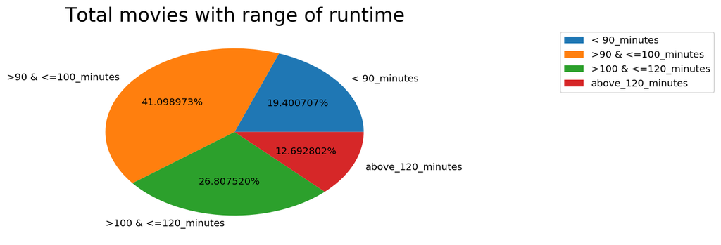

```python
#plotting movies based on range of runetime in minutes
under_90_minutes=df_movie[df_movie['runtime']<90]
runtime90_100_minutes=df_movie[(df_movie['runtime'] >80) & (df_movie['runtime']<=100)]
runtime100_120_minutes=df_movie[(df_movie['runtime'] >100) & (df_movie['runtime']<=120)]
above_120_minutes=df_movie[df_movie['runtime'] > 120]
miki=np.array([under_90_minutes['original_title'].count(),runtime90_100_minutes['original_title'].count(),
               runtime100_120_minutes['original_title'].count(),above_120_minutes['original_title'].count()])
mylabels=['< 90_minutes','>90 & <=100_minutes','>100 & <=120_minutes','above_120_minutes']
plt.title("Total movies with range of runtime",fontsize=20)
plt.pie(miki,labels=mylabels,autopct='%1f%%')
plt.legend(bbox_to_anchor=(2,1))
plt.show()
```

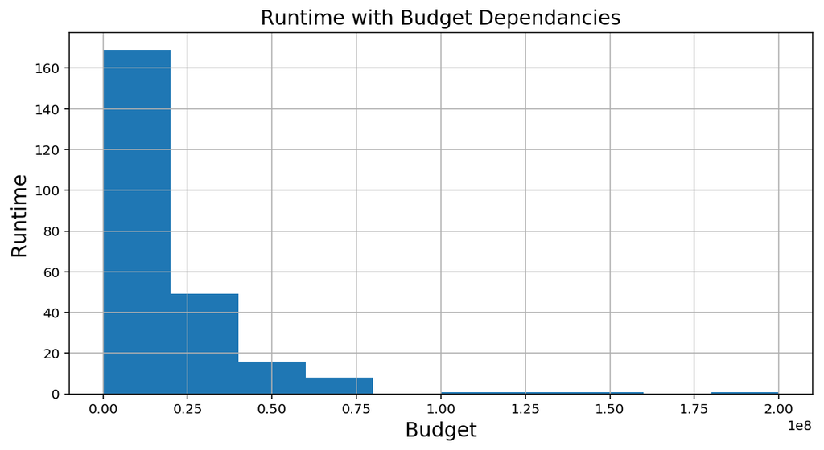

```python
# Drawing runtime with budget dependancies
run_budget=df_movie.groupby('runetime')['budget'].mean()
run_budget.hist(figsize=(10,5))
plt.title("Runtime with Budget Dependancies",fontsize=15)
plt.xlabel("Budget",fontsize=15)
plt.ylabel("Runtime",fontsize=15)
plt.show();
```

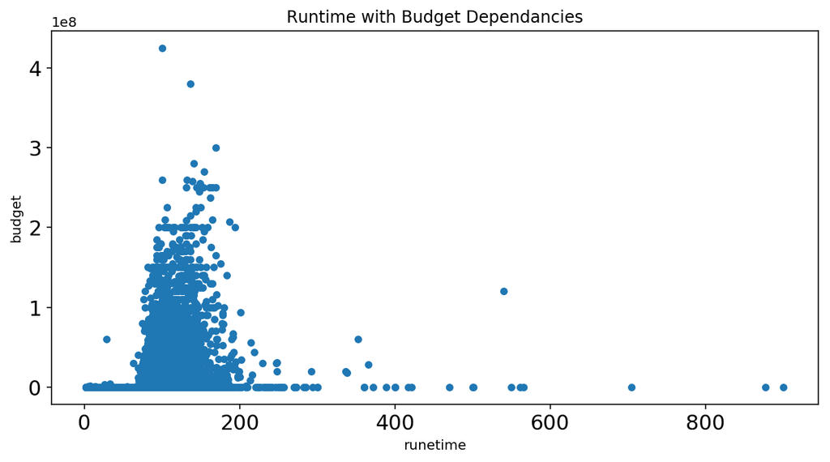

```python
# Drawing runtime with budget dependancies using Scatter
df_movie.plot(x='runetime',y="budget",kind="scatter",fontsize=15, title="Runtime with Budget Dependancies",figsize=(10,5));
```

### Research Question 3 : ( Top 5 Movies with the highest budget ?)

For this analysis question i will explore the top 5 movies with highest budget

```python
# Finding Top 5 movies with the highest budget
top_5=df_movie[['original_title',"budget",'genres']].nlargest(n=5,columns='budget')
top_5
```

|  | original_title | budget | genres |
| --- | --- | --- | --- |
| 2244 | The Warrior's Way | 425000000 | Adventure\|Fantasy\|Action\|Western\|Thriller |
| 3375 | Pirates of the Caribbean: On Stranger Tides | 380000000 | Adventure\|Action\|Fantasy |
| 7387 | Pirates of the Caribbean: At World's End | 300000000 | Adventure\|Fantasy\|Action |
| 14 | Avengers: Age of Ultron | 280000000 | Action\|Adventure\|Science Fiction |
| 6570 | Superman Returns | 270000000 | Adventure\|Fantasy\|Action\|Science Fiction |

> **Notice:**In the above analysis i have explored top 5 movies with highest budget which are: "The Warrior's Way ", "Pirates of the Caribbean: On Stranger Tides","Pirates of the Caribbean: At World's End","Avengers: Age of Ultron" and "Superman Returns" respectively.

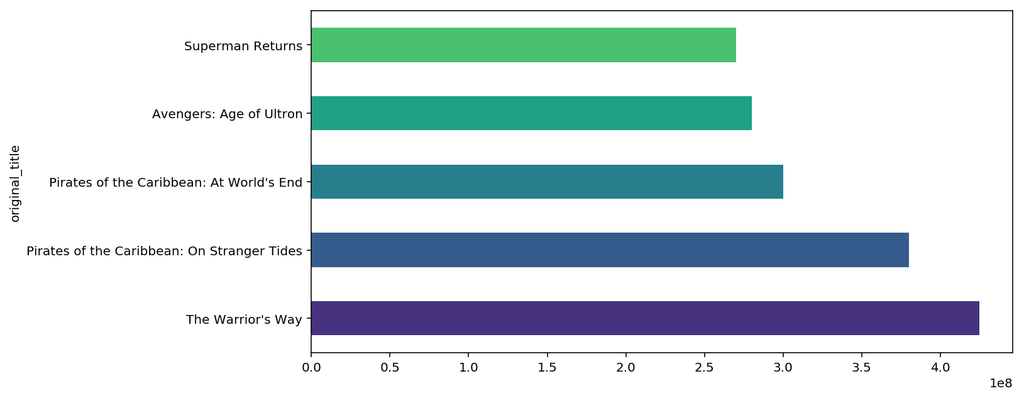

```python
#Ploting top 5 movies with  highest budget
top_5.set_index('original_title')["budget"].nlargest(5).plot(kind='barh',figsize=(10,5),color=sns.color_palette('viridis'));
```

### Research Question 4 : (Average runtime of the movies?)

```python
# Finding the average runtime of the movies
df_movie['runtime'].mean()
```

```
102.07179015186378
```

**Notice:** The average runtime of the movies in the entire dataset is **102.07 minutes**

#### Creating a group of the data based on their release_year and find the mean related to this and plot.

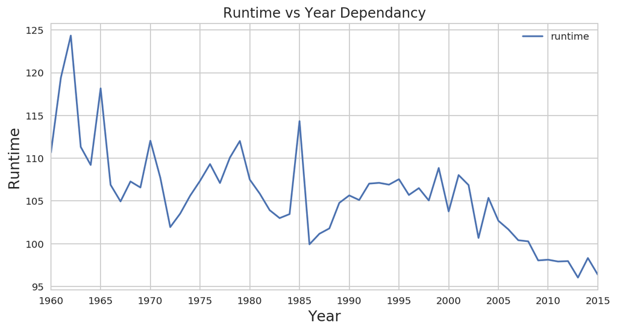

```python
#ploting the dependency between Runtime and Year_realse of the movie .
df_movie.groupby('release_year').mean()['runtime'].plot(xticks = np.arange(1960,2016,5))
#setup the figure size.
sns.set(rc={'figure.figsize':(10,5)})
#setup the title of the figure
plt.title("Runtime vs Year Dependancy",fontsize = 14)

#setup the x-label and y-label of the plot.
plt.xlabel('Year',fontsize = 15)
plt.ylabel('Runtime',fontsize = 15)
sns.set_style("whitegrid")
plt.legend()
plt.show()
```

### Research Question 5 : (Most movies from which geners?)

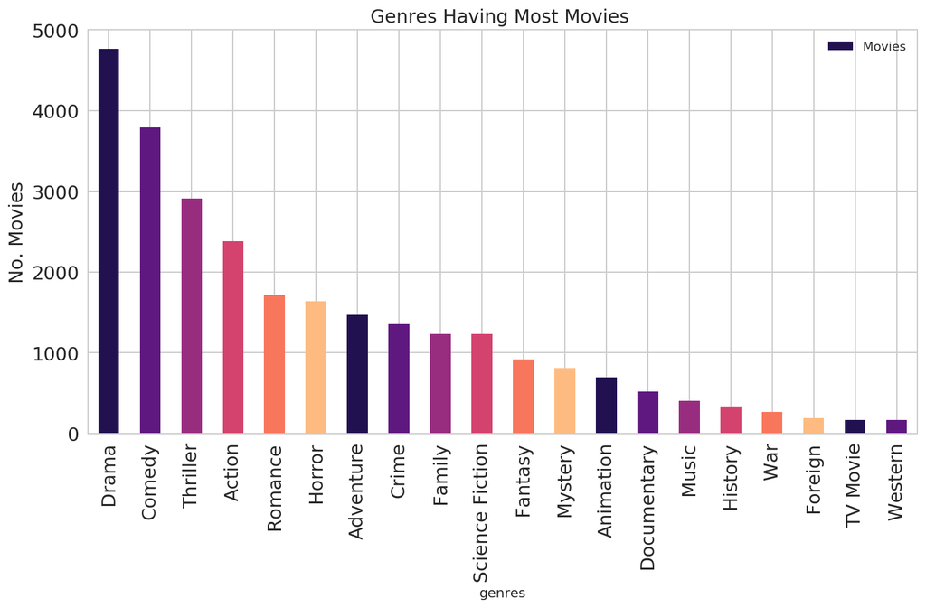

```python
# split genres string, at |, explode the list to rows
genres_df = df_movie.assign(genres=df_movie['genres'].str.split('|')).explode('genres')

# To show individual geners which have more movies
genres_df.groupby("genres").size().sort_values(ascending=False).head(20).plot(kind='bar',figsize=(12,6),
                                                                color=sns.color_palette('magma'),fontsize=15);
plt.legend(['Movies'])
plt.ylabel("No. Movies", fontsize=15);
plt.title("Genres Having Most Movies ",fontsize=15 );
```

> **Notice:** the above bar graph shows individual genres which have most movies

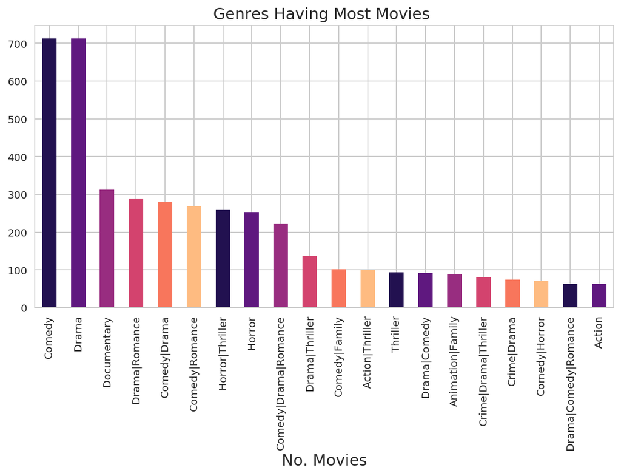

```python
# To show combined geners which have more movies
most_Movies=df_movie.groupby("genres").size().sort_values(ascending=False)
most_Movies.head(20).plot(kind='bar',figsize=(10,5),color=sns.color_palette('magma'));
plt.xlabel("No. Movies", fontsize=15);
plt.title("Genres Having Most Movies ",fontsize=15 );
```

> **Notice:**The above bar graph shows the order of the **combined geners** which have more movies

```python
#Grouping exploded dataframe by genres and geting average popularity
genres_df = df_movie.assign(genres=df_movie['genres'].str.split('|')).explode('genres')
genres_df.groupby('genres').popularity.mean()
```

```
genres
Action             0.926274
Adventure          1.154259
Animation          0.852182
Comedy             0.592607
Crime              0.744930
Documentary        0.181432
Drama              0.591495
Family             0.786668
Fantasy            0.992840
Foreign            0.191496
History            0.575936
Horror             0.465357
Music              0.487321
Mystery            0.690012
Romance            0.592082
Science Fiction    1.001548
TV Movie           0.270896
Thriller           0.741563
War                0.727683
Western            0.590615
Name: popularity, dtype: float64
```

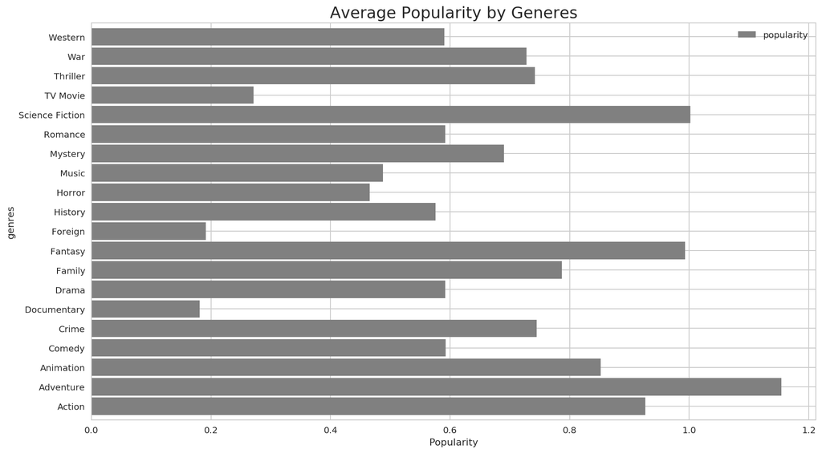

```python
# plotting  Geners groubed by the average popularity
genres_df.groupby('genres').popularity.mean().plot.barh(color=['gray'],width=0.9,figsize=[14.70,8.27],rot=0);
#Title and Labels
plt.legend()
plt.xlabel("Popularity")
plt.title("Average Popularity by Generes",fontsize=18)
plt.show();
```

```python
#average Popularity
df_movie['popularity'].mean()
```

```
0.6464455549010584
```

> **Notice:** From the above statistical calculation the average popularity of the movies is **0.64**

## Conclusions

Finally, we don't know whether the datasets provided to us is completely correct and newly collected,because now a day data is modified and stored in very fast way. inorder to make a correct analysis and exploration we should have accurate datasets.

## Submitting your Project

> **Tip**: Before you submit your project, you need to create a .html or .pdf version of this notebook in the workspace here. To do that, run the code cell below. If it worked correctly, you should get a return code of 0, and you should see the generated .html file in the workspace directory (click on the orange Jupyter icon in the upper left).

> **Tip**: Alternatively, you can download this report as .html via the **File** > **Download as** submenu, and then manually upload it into the workspace directory by clicking on the orange Jupyter icon in the upper left, then using the Upload button.

> **Tip**: Once you've done this, you can submit your project by clicking on the "Submit Project" button in the lower right here. This will create and submit a zip file with this .ipynb doc and the .html or .pdf version you created. Congratulations!

```python
from subprocess import call
call(['python', '-m', 'nbconvert', 'Investigate_a_Dataset.ipynb'])
```

```
0
```